# Matson_670_final

## Sentiment and Skepticism in tweets referencing global warming

#### MIS 670

Climate change is an increasingly polarizing topic. In recent history world temperatures have slowly been increasing. Over the last ten years, the pace of increase is accelerating. The scientific community is united behind the idea that manmade impact is causing the recent increase in temperatures. Scientist point to the raise in greenhouse gasses as the biggest contributor to higher temperatures. Greenhouses gasses allow sunlight to pass through into earth, but traps of the energy that normally is radiated back out to space. Evidence of damage to the earth can be seen by warming oceans, shrinking ice sheets, glacial retreat, decreased snow cover and sea level rise. If the current trends go unchecked, the artic will become ice free in the summer, sea level will rise 1-4 ft, hurricanes will become stronger, drought and head waves will be more extreme and precipitation patterns will continue to change.  
Despite the scientific evidence, some remain skeptical man has any influence on the weather patterns. Even though the amount of carbon dioxide in the air has increased drastically over the past 50 years, it still accounts for only 0.04% of the atmosphere. Skeptics use this to argue that it cannot have a large effect on global temperatures because water vapor is also a greenhouse gas and makes up a much higher proportion of the atmosphere. Skeptics also point to the last couple years being slightly cooler than before to point to a new trend of global cooling. Another theory include heightened sun activity caused the recent run up in temperatures and temperatures will start to cool when sun activity decreases. If climate change is indeed manmade, the time to change our behavior and combat climate change is now. The longer we wait, the direr the situation becomes. Currently there is no political will to enact the policies and laws that are required to combat climate change. The upcoming presidential election will have a great impact on if the government will start to take action to mitigate possible climate changing behavior. The main goal of this project is to analyze twitter data for present time (April 2019), April 2015, and April 2011 to see if there are any significant differences between the sentiment and skepticism of tweets in these time periods. Any changes in the present time may signal a shift in voter sentiment with respect to global warming.

### Data Collection

```python
#Import packages
import csv
import pandas as pd
import re
import json
from collections import Counter
import nltk
from nltk.corpus import stopwords
from nltk.corpus import words
from vaderSentiment.vaderSentiment import SentimentIntensityAnalyzer
from wordcloud import WordCloud, STOPWORDS
from nltk.corpus import stopwords
from nltk.stem import WordNetLemmatizer
import matplotlib.pyplot as plt
%matplotlib inline

# feature engineering (words to vectors)
from sklearn.feature_extraction.text import TfidfVectorizer

# classification algorithms (or classifiers)
from sklearn.naive_bayes import MultinomialNB
from sklearn.neighbors import KNeighborsClassifier
from sklearn.svm import SVC, LinearSVC

# build a pipeline
from sklearn.pipeline import Pipeline

# model evaluation, validation
from sklearn.metrics import classification_report, f1_score, accuracy_score, confusion_matrix
from sklearn.model_selection import StratifiedKFold, cross_val_score, train_test_split, GridSearchCV
from sklearn import metrics
from sklearn.metrics import roc_curve, auc

import scikitplot as skplt
import numpy as np

from sklearn.neural_network import MLPClassifier
import seaborn as sns
```

### Data processing

```python
# create an empty list to store our tweets in
data = []

# append each line of the data to our tweets list using the json module
for line in open('twitterclidata.json'):
    try:
        data.append(json.loads(line))
    except:
        pass

# lets see how many we got
print(len(data))
```

```
446097
```

```python
#Only select english tweets
english = []

# for loop
for i in data:
    if i['user']['lang'] == 'en':
        english.append(i)
len(english)
```

```
376007
```

```python
#Check data
for i in english[:5]:
    print(i['text'])
```

```
RT @ElizabethGerv12: It always boils down to money for the GOP. #Disgraceful https://t.co/asimku5bUZ
RT @GottaLaff: #ClimateChangeIsReal https://t.co/5c0VWRTbhe
RT @GottaLaff: #ClimateChangeIsReal https://t.co/5c0VWRTbhe
RT @SkyNews: "I'm writing two dissertations right now, but I'd like a future to graduate into."

Katie has been chained to concrete for six…
RT @stampwords: ไทยควรจริงจังกับเรื่อง climate change ภาวะโลกร้อน แบบจริงจังแล้วนะ คือมันเป็นเรื่องของทั้งโลก แต่ตะกี้อ่านเจอว่าอีก30ปี ในบ…
```

```python
#how many tweets contain geocode

geo = [T['user']['geo_enabled'] for T in english if 'user' in T]

c = Counter(geo)
print(c)
```

```
Counter({False: 226706, True: 149301})
```

```python
# More codes for extracting information from tweets

ids = [T['id_str'] for T in english]
times = [T['created_at'] for T in english]
texts = [T['text'] for T in english]
screen_names = [T['user']['screen_name'] for T in english]
followers_count = [T['user']['followers_count'] for T in english]
friends_count = [T['user']['friends_count'] for T in english]
names = [T['user']['name'] for T in english]


# open an output csv file to write to
out = open('tweetclidata.csv', 'w', encoding='UTF-8', newline='')

# write the header of our CSV as its first line
out.write('id,created at,text,screen name,followers_count,friends_count,name\n')

# merge each individual list into a single list using the zip function
rows = list(zip(ids, times, texts, screen_names, followers_count, friends_count, names))

# use the writer module on our csv file
csv = csv.writer(out)

# use one value from each of our rows list and write it to the csv as a new row
for row in rows:
    values = [value for value in row]
    csv.writerow(values)

# close our csv file when done
out.close()
```

```python
#Import data as csv
df = pd.read_csv("tweetclidata.csv")
df.head()
```

|  | id | created at | text | screen name | followers_count | friends_count | name |
| --- | --- | --- | --- | --- | --- | --- | --- |
| 0 | 1118578261108383745 | Wed Apr 17 18:13:34 +0000 2019 | RT @PickardJE: some climate change statistics ... | rawshea18 | 246 | 424 | rawshea |
| 1 | 1118578260923887620 | Wed Apr 17 18:13:34 +0000 2019 | RT @toryboypierce: Withering putdown of pompo... | AndrewOldham20 | 534 | 76 | Andrew Oldham |
| 2 | 1118578261662027777 | Wed Apr 17 18:13:34 +0000 2019 | RT @Channel4News: This is the moment an enviro... | GhadeerAl_ | 144 | 149 | Ghadeer |
| 3 | 1118578262509268999 | Wed Apr 17 18:13:34 +0000 2019 | RT @AOC: Climate change is here + we’ve got a ... | kayjoooo | 180 | 334 | ˗ˏˋ KATIE ˊˎ˗ |
| 4 | 1118578264463876098 | Wed Apr 17 18:13:35 +0000 2019 | RT @AOC: Climate change is here + we’ve got a ... | BagOfLazers | 753 | 1712 | Bag Of Lazers |

```python
# crate a column named "hash" and store all hashtags
df['hash'] = df.text.str.findall("(?<=#)\w+")
df['hash'] = df['hash'].apply(' '.join)
```

```python
#Create a column named ment and store all mentions
df['ment'] = df.text.str.findall("(?<=@)\w+")
df['ment'] = df['ment'].apply(' '.join)
```

```python
#Create a column named wordcount and store how many words in each tweet
df['wordcount'] = df['text'].str.split().str.len()
```

```python
#Create a column named counts and store the number of characters in each tweet.
df['counts'] = df['text'].str.len()
```

```python
#Create a column named retweet with true/false if the tweet is a retweet or not.
df['retweet'] = df.text.str.startswith("RT")

len(df)
```

```
376007
```

```python
extra = set(('change', 'climate', 'got', 'left'))
stop = set(stopwords.words('english')) | extra

#It is necessary to clean the data for some processing.  First create a copy of the tweet in a separate column named cleaned.
df['cleaned'] = df['text']
#Change all letters to lower case
df['cleaned'] = df['cleaned'].str.lower()
#Remove all urls
df['cleaned'] = df.cleaned.str.replace('http\S+|www.\S+', '')
#Replace all non alphabetic charachters
df['cleaned'] = df['cleaned'].str.replace("[^a-zA-Z]", " ")
#Remove all words with 3 or less charachters
df['cleaned'] = df.cleaned.str.findall('\w{3,}').str.join(' ')
#Remove all stop words
df['cleaned'] = df.cleaned.apply(lambda x: ' '.join([word for word in x.split() if word not in (stop)]))
```

```python
#Analyse 8 year old tweets
df2011 = pd.read_csv('8yearoldtweets.csv')
df2011 = df2011[['tweets']]
df2011.head()
```

|  | tweets |
| --- | --- |
| 0 | DroughtDoctor;2011-04-29 18:57;0;0;"Colleagues... |
| 1 | Innovation2;2011-04-29 18:56;0;0;"New Post: St... |
| 2 | mattstrand;2011-04-29 18:55;0;0;"This is an ex... |
| 3 | Yolibeans;2011-04-29 18:55;0;0;"is now being r... |
| 4 | EarthKnowledge;2011-04-29 18:55;0;0;"UNFCCC: I... |

```python
#Clean data for analysis
df2011['tweets'] = df2011['tweets'].astype(str)
df2011['tweets'] = df2011['tweets'].str.lower()
df2011['tweets'] = df2011['tweets'].str.replace("[^a-zA-Z]", " ")
df2011['tweets'] = df2011['tweets'].str.findall('\w{3,}').str.join(' ')
df2011['tweets'] = df2011['tweets'].apply(lambda x: ' '.join([word for word in x.split() if word not in (stop)]))
```

```python
#Analyize 4 year old tweets
df2015 = pd.read_csv('4yearoldtweets.csv')
df2015 = df2015[['tweets']]
df2015.head()
```

|  | tweets |
| --- | --- |
| 0 | karenagold;2015-04-29 18:59;1;0;"Scheduled to ... |
| 1 | dflessner1;2015-04-29 18:59;0;0;"Former Bush E... |
| 2 | tomfeyer;2015-04-29 18:58;1;0;"Beyond the # Po... |
| 3 | OandG_Advice;2015-04-29 18:58;0;0;"Invisible o... |
| 4 | CorinnaThomas;2015-04-29 18:58;0;0;"CLIMATE CH... |

```python
#Clean data for analysis
df2015['tweets'] = df2015['tweets'].astype(str)
df2015['tweets'] = df2015['tweets'].str.lower()
df2015['tweets'] = df2015['tweets'].str.replace("[^a-zA-Z]", " ")
df2015['tweets'] = df2015['tweets'].str.findall('\w{3,}').str.join(' ')
df2015['tweets'] = df2015['tweets'].apply(lambda x: ' '.join([word for word in x.split() if word not in (stop)]))
```

### Sentiment Analysis

```python
#We will use Vader Sentiment analysis.  Create a column with each tweet rated as positive, negative or neutral sentiment.
vs = SentimentIntensityAnalyzer()
df['score'] = pd.cut(df['text'].apply(lambda x: vs.polarity_scores(x)['compound']), [-10, -0.1, 0.1, 10],
                                            labels=['negative', 'neutral', 'positive'])
df['scorefl'] = df['text'].apply(lambda x: vs.polarity_scores(x)['compound'])
```

```python
#Create an index for each sentiment category

positive = (df['score'] == 'positive')
neutral = (df['score'] == 'neutral')
negative = (df['score'] == 'negative')
```

```python
#Apply Vader sentiment analysis to tweets
vs = SentimentIntensityAnalyzer()
df2015['score'] = pd.cut(df2015['tweets'].apply(lambda x: vs.polarity_scores(x)['compound']), [-10, -0.1, 0.1, 10],
                                            labels=['negative', 'neutral', 'positive'])
df2015['scorefl'] = df2015['tweets'].apply(lambda x: vs.polarity_scores(x)['compound'])
```

```python
#Apply vader sentiment analsysis
vs = SentimentIntensityAnalyzer()
df2011['score'] = pd.cut(df2011['tweets'].apply(lambda x: vs.polarity_scores(x)['compound']), [-10, -0.1, 0.1, 10],
                                            labels=['negative', 'neutral', 'positive'])
df2011['scorefl'] = df2011['tweets'].apply(lambda x: vs.polarity_scores(x)['compound'])
```

```python
#Check the number of tweets in each sentiment category
df['score'].value_counts()
```

```
positive    154016
negative    128482
neutral      93509
Name: score, dtype: int64
```

```python
#Show number of tweets in each sentiment category
df2011['score'].value_counts()
```

```
negative    428
neutral     302
positive    270
Name: score, dtype: int64
```

```python
#Check how many tweets in each sentiment category
df2015['score'].value_counts()
```

```
neutral     398
negative    316
positive    286
Name: score, dtype: int64
```

### Exploratory Analysis

```python
#Check the top URLS
urls = []
for T in english:
    for i in T['entities']['urls']:
        urls.append(i['url'])

c=Counter(urls)
c.most_common(10)
```

```
[('https://t.co/3I0xZ0fHNF', 995),
 ('https://t.co/KHcgyOaSaz', 882),
 ('https://t.co/Dy3zVUYi9m', 714),
 ('https://t.co/0ucFOLEgTj', 675),
 ('https://t.co/CO89hSBtZI', 502),
 ('https://t.co/p3luh9RoPy', 488),
 ('https://t.co/KhC80HEEwZ', 437),
 ('https://t.co/fmmHAFAc38', 398),
 ('https://t.co/xesqpMSRk6', 354),
 ('https://t.co/LIo7EJIUy9', 325)]
```

We can get an idea about the trends going on during data collection by checking the top 10 URLS. 2 URLS are about a concert with proceeds promised to combat climate change, 1 is critizinging climate protests in England, and the rest are scientic articles supporting climate change. No sign of skepticim here.

```python
#Check the users with the highest friend count
df.sort_values(by='friends_count', ascending=False).head(10)
```

|  | id | created at | text | screen name | followers_count | friends_count | name | hash | ment | wordcount | counts | retweet | cleaned | score | scorefl |
| --- | --- | --- | --- | --- | --- | --- | --- | --- | --- | --- | --- | --- | --- | --- | --- |
| 369874 | 1119269703485202434 | Fri Apr 19 16:01:06 +0000 2019 | Is climate change a massive hoax or not? Whic... | jilevin | 613848 | 499247 | Jeffrey Levin | green |  | 14 | 97 | False | massive hoax makes sense green | negative | -0.3527 |
| 332985 | 1119220751956152320 | Fri Apr 19 12:46:36 +0000 2019 | Climate change emerges as top 2020 campaign is... | jilevin | 613814 | 498974 | Jeffrey Levin |  |  | 14 | 106 | False | emerges top campaign issue iowa devastating fl... | negative | -0.5423 |
| 132776 | 1118861348165836800 | Thu Apr 18 12:58:27 +0000 2019 | Democrats Are United on Climate Change, but No... | jilevin | 613650 | 498786 | Jeffrey Levin |  |  | 15 | 94 | False | democrats united | positive | 0.2263 |
| 83752 | 1118744102869381120 | Thu Apr 18 05:12:34 +0000 2019 | Environmentalists say climate change to blame ... | jilevin | 613624 | 498613 | Jeffrey Levin |  |  | 15 | 119 | False | environmentalists say blame weary polar bear a... | negative | -0.5423 |
| 13290 | 1118597771077062656 | Wed Apr 17 19:31:05 +0000 2019 | Scientists blame climate change for Hurricane ... | jilevin | 613583 | 489636 | Jeffrey Levin |  |  | 10 | 96 | False | scientists blame hurricane maria devastating d... | negative | -0.7717 |
| 348711 | 1119243185551601665 | Fri Apr 19 14:15:44 +0000 2019 | RT @h0einthemirror: Never forget 23 years ago ... | PleasureEllis | 768510 | 431856 | Pleasure Ellis™️ |  | h0einthemirror | 22 | 140 | True | einthemirror never forget years ago michael wa... | neutral | 0.0428 |
| 348629 | 1119243085655859201 | Fri Apr 19 14:15:20 +0000 2019 | RT @Annie_Is_Not_OK: Michael Jackson was warni... | PleasureEllis | 768510 | 431856 | Pleasure Ellis™️ |  | Annie_Is_Not_OK | 23 | 139 | True | annie michael jackson warning nearly years nev... | negative | -0.6842 |
| 301089 | 1119168049385484288 | Fri Apr 19 09:17:10 +0000 2019 | RT @MeanwhileinCana: Just a friendly reminder ... | bynsny | 272761 | 387460 | Larry Kelly |  | MeanwhileinCana | 20 | 139 | True | meanwhileincana friendly reminder petty bicker... | positive | 0.3400 |
| 301184 | 1119168273206128640 | Fri Apr 19 09:18:04 +0000 2019 | RT @EcofiscalCanada: Failing to act on climate... | bynsny | 272761 | 387460 | Larry Kelly |  | EcofiscalCanada | 22 | 140 | True | ecofiscalcanada failing act worse yet backslid... | negative | -0.8658 |
| 172184 | 1118934804374925312 | Thu Apr 18 17:50:20 +0000 2019 | RT @AllanMargolin: #ClimateAction Quote of the... | ChaelMontgomery | 432689 | 382165 | #ChaelMontgomery | ClimateAction | AllanMargolin | 20 | 140 | True | allanmargolin climateaction quote day greatest... | positive | 0.2023 |

```python
#Check the users with highest follower counts
df.sort_values(by='followers_count', ascending=False).head(10)
```

|  | id | created at | text | screen name | followers_count | friends_count | name | hash | ment | wordcount | counts | retweet | cleaned | score | scorefl |
| --- | --- | --- | --- | --- | --- | --- | --- | --- | --- | --- | --- | --- | --- | --- | --- |
| 232455 | 1119027886885953536 | Fri Apr 19 00:00:13 +0000 2019 | We asked all 18 declared Democratic presidenti... | nytimes | 43250401 | 889 | The New York Times |  |  | 20 | 140 | False | asked declared democratic presidential candida... | neutral | 0.0772 |
| 126671 | 1118850434586816512 | Thu Apr 18 12:15:05 +0000 2019 | For Democrats vying to unseat President Trump,... | nytimes | 43246830 | 889 | The New York Times |  |  | 20 | 140 | False | democrats vying unseat president trump acknowl... | positive | 0.4404 |
| 70276 | 1118703209890156546 | Thu Apr 18 02:30:04 +0000 2019 | New York City is about to embark on an ambitio... | nytimes | 43244116 | 889 | The New York Times |  |  | 23 | 140 | False | new york city embark ambitious plan fight woul... | positive | 0.1280 |
| 51609 | 1118661697236033536 | Wed Apr 17 23:45:07 +0000 2019 | Climates activists glued themselves to a Londo... | nytimes | 43243382 | 889 | The New York Times |  |  | 19 | 140 | False | climates activists glued london commuter train... | negative | -0.2732 |
| 102204 | 1118793267187941378 | Thu Apr 18 08:27:55 +0000 2019 | Possibly the most effective thing we can do to... | CNN | 41746546 | 1109 | CNN |  |  | 17 | 118 | False | possibly effective thing fight plant trillion ... | positive | 0.2006 |
| 8298 | 1118589977770770433 | Wed Apr 17 19:00:07 +0000 2019 | Possibly the most effective thing we can do to... | CNN | 41742434 | 1109 | CNN |  |  | 17 | 118 | False | possibly effective thing fight plant trillion ... | positive | 0.2006 |
| 362111 | 1119259561108615172 | Fri Apr 19 15:20:48 +0000 2019 | "In a perverse way, the extreme weather that w... | TheEconomist | 23670605 | 0 | The Economist |  |  | 22 | 139 | False | perverse way extreme weather seeing last coupl... | negative | -0.4215 |
| 28412 | 1118622188003909635 | Wed Apr 17 21:08:07 +0000 2019 | Is there any way to stop climate change? Drast... | TheEconomist | 23667112 | 0 | The Economist |  | dwallacewells | 17 | 126 | False | way stop drastic political action needed dwall... | negative | -0.2960 |
| 315193 | 1119193739396825088 | Fri Apr 19 10:59:15 +0000 2019 | RT @LeoDiCaprio: Thank you to @lildickytweets ... | ShawnMendes | 21649281 | 58092 | Shawn Mendes |  | LeoDiCaprio lildickytweets | 23 | 140 | True | leodicaprio thank lildickytweets artists came ... | positive | 0.6597 |
| 372749 | 1119273587662315520 | Fri Apr 19 16:16:33 +0000 2019 | Climate change protesters descend on France's ... | Reuters | 20378497 | 1085 | Reuters Top News |  |  | 11 | 118 | False | protesters descend france socgen energy companies | neutral | 0.0516 |

Most influential twitter users (top friend and followers) are all supportive of climate change.

```python
#Now list the top 10 most popular mentions in positive tweets
fdistnment = list(Counter(" ".join(df[positive]['ment']).split(" ")).items())
freqn_ment = []

for k,v in fdistnment:
    freqn_ment.append([k,v])

mentnlist = pd.DataFrame(freqn_ment)
mentnlist.sort_values(by=1, ascending=False).head(10)
```

|  | 0 | 1 |
| --- | --- | --- |
| 73 | DanFisha | 29535 |
| 1 |  | 17592 |
| 143 | lildickytweets | 10663 |
| 407 | LeoDiCaprio | 10523 |
| 389 | ChrisGPackham | 7729 |
| 14 | AOC | 4539 |
| 4124 | BBCOne | 3190 |
| 369 | NaomiAKlein | 2402 |
| 333 | CarolineLucas | 2280 |
| 5 | GretaThunberg | 2239 |

```python
#Show the top 10 mentions for negative tweets
fdistnment = list(Counter(" ".join(df[negative]['ment']).split(" ")).items())
freqn_ment = []

for k,v in fdistnment:
    freqn_ment.append([k,v])

mentnlist = pd.DataFrame(freqn_ment)
mentnlist.sort_values(by=1, ascending=False).head(10)
```

|  | 0 | 1 |
| --- | --- | --- |
| 16 |  | 18004 |
| 2 | AOC | 15756 |
| 372 | SenSanders | 4156 |
| 18 | danielhowell | 2880 |
| 27 | cakedsnowbunny | 2228 |
| 2469 | BBCOne | 1791 |
| 8991 | CraigBennett3 | 1743 |
| 93 | TerrenceEdwards | 1536 |
| 37 | ExtinctionR | 1268 |
| 52 | ValentinaYamil | 1198 |

All the top mentions support climate change except DanFisha. Interesting that the top mention comes from an account with about 1000 followers.

```python
#Check the top 10 hastags for positive tweets
fdistphash = list(Counter(" ".join(df[positive]['hash']).split(" ")).items())
freqp_hash = []

for k,v in fdistphash:
    freqp_hash.append([k,v])

hashplist = pd.DataFrame(freqp_hash)
hashplist.sort_values(by=1, ascending=False).head(10)
```

|  | 0 | 1 |
| --- | --- | --- |
| 0 |  | 131049 |
| 930 | ClimateCatastrophe | 8235 |
| 1113 | ClimateChangeTheFacts | 2029 |
| 8 | ClimateChange | 1464 |
| 1691 | ClimateChangeTheF | 1234 |
| 1 | ExtinctionRebellion | 1027 |
| 4 | GreenNewDeal | 613 |
| 16 | climatechange | 480 |
| 507 | ClimateStrike | 475 |
| 262 | London | 472 |

```python
#Check the top 10 hastags for negative tweets
fdistphash = list(Counter(" ".join(df[negative]['hash']).split(" ")).items())
freqp_hash = []

for k,v in fdistphash:
    freqp_hash.append([k,v])

hashplist = pd.DataFrame(freqp_hash)
hashplist.sort_values(by=1, ascending=False).head(10)
```

|  | 0 | 1 |
| --- | --- | --- |
| 0 |  | 101454 |
| 1 | GreenNewDeal | 15778 |
| 9 | ClimateChange | 2364 |
| 17 | Climat | 1602 |
| 16 | OurPlanet | 1568 |
| 15 | Walrus | 1535 |
| 11 | ExtinctionRebellion | 1079 |
| 24 | climatechange | 507 |
| 851 | Demonrats | 380 |
| 691 | ClimateChangeTheFacts | 360 |

```python
#Check the average values for each sentiment category
df.groupby('score').mean()
```

| score | id | followers_count | friends_count | wordcount | counts | retweet | scorefl |
| --- | --- | --- | --- | --- | --- | --- | --- |
| negative | 1.118895e+18 | 8447.635957 | 1733.452421 | 21.646908 | 133.188353 | 0.776700 | -0.445175 |
| neutral | 1.118952e+18 | 7537.715920 | 1912.411885 | 18.469794 | 123.111743 | 0.683645 | 0.000442 |
| positive | 1.118988e+18 | 5657.354171 | 1455.023842 | 20.889804 | 133.258486 | 0.806260 | 0.381575 |

Basic statistics for each sentiment category are similiar.

```python
#Check the average tweet sentiment rating
df['scorefl'].mean()
```

```
0.004289568279333489
```

Since VADER sentiment scores seem to run high, a 0.004 average score would suggest slightly negative sentiment around 'climate change'.

```python
#Check the top wordcount for positive tweets
fdistp = list(Counter(" ".join(df[positive]['cleaned']).split(" ")).items())
freqp = []

for k,v in fdistp:
    freqp.append([k,v])

wordlistp = pd.DataFrame(freqp)
wordlistp.sort_values(by=1, ascending=False).head(10)
```

|  | 0 | 1 |
| --- | --- | --- |
| 152 | making | 31877 |
| 577 | large | 30572 |
| 578 | scale | 29973 |
| 311 | changes | 29800 |
| 573 | governments | 29700 |
| 579 | order | 29651 |
| 575 | seriousness | 29635 |
| 574 | acknowledging | 29599 |
| 572 | offense | 29585 |
| 576 | actively | 29566 |

```python
#Check the top wordcount for negative tweets
fdistn = list(Counter(" ".join(df[negative]['cleaned']).split(" ")).items())
freqn = []

for k,v in fdistn:
    freqn.append([k,v])

wordlistn = pd.DataFrame(freqn)
wordlistn.sort_values(by=1, ascending=False).head(10)
```

|  | 0 | 1 |
| --- | --- | --- |
| 12 | years | 22863 |
| 18 | world | 18633 |
| 14 | emissions | 16716 |
| 17 | plan | 16244 |
| 10 | aoc | 16038 |
| 13 | cut | 15848 |
| 16 | greennewdeal | 15784 |
| 15 | half | 15738 |
| 11 | deadline | 15584 |
| 287 | global | 8438 |

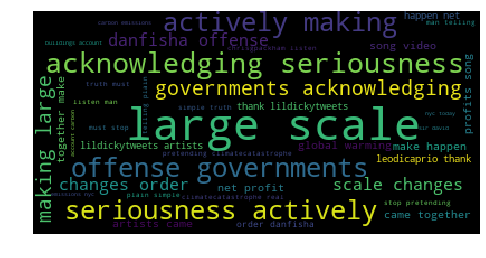

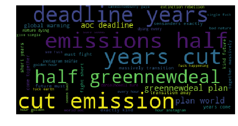

```python
#Show positive wordcloud
wordcloud1 = WordCloud(max_words = 40,max_font_size=40, relative_scaling=.5, stopwords = stop).generate(' '.join(df[positive]['cleaned']))
plt.figure(figsize=(8,8))
plt.imshow(wordcloud1)
plt.axis("off")
plt.show()
#Show negative word cloud
wordcloud2 = WordCloud(max_words = 40,max_font_size=40, relative_scaling=.5, stopwords= stop).generate(' '.join(df[negative]['cleaned']))
plt.figure(figsize=(8,8))
plt.imshow(wordcloud2)
plt.axis("off")
plt.show()
```

```python
#Save to csv, ensure data is saved
df.to_csv('processesdf.csv', )
```

### Skepticism Analasis via text classification

Skepticism is a difficult challange when analizing tweets mentioning 'climate change'. Topic modeling will not seperate the tweets, the difference is subtle. It is possible to use text classification, but the tweets will have to be manually labeled before feeding into the algorithm. Then, we can label use the prediction to label the rest of the tweets. There are many tweets that do not explicitly support or are skeptical of 'climate change'. For simplicity, we have grouped these with supporting tweets, and attached labels of skeptical (0) and not skeptical (1)

```python
#Import csv
df_proc = pd.read_csv("processesdf.csv")
df_proc.head()
```

|  | Unnamed: 0 | id | created at | text | screen name | followers_count | friends_count | name | hash | ment | wordcount | counts | retweet | cleaned | score | scorefl |
| --- | --- | --- | --- | --- | --- | --- | --- | --- | --- | --- | --- | --- | --- | --- | --- | --- |
| 0 | 0 | 1118578261108383745 | Wed Apr 17 18:13:34 +0000 2019 | RT @PickardJE: some climate change statistics ... | rawshea18 | 246.0 | 424.0 | rawshea | NaN | PickardJE | 7 | 69 | True | pickardje statistics | neutral | 0.0000 |
| 1 | 1 | 1118578260923887620 | Wed Apr 17 18:13:34 +0000 2019 | RT @toryboypierce: Withering putdown of pompo... | AndrewOldham20 | 534.0 | 76.0 | Andrew Oldham | NaN | toryboypierce adamboultonSKY | 20 | 140 | True | toryboypierce withering putdown pompous fascis... | negative | -0.7717 |
| 2 | 2 | 1118578261662027777 | Wed Apr 17 18:13:34 +0000 2019 | RT @Channel4News: This is the moment an enviro... | GhadeerAl_ | 144.0 | 149.0 | Ghadeer | NaN | Channel4News | 22 | 140 | True | channel news moment environmental lawyer glues... | neutral | 0.0000 |
| 3 | 3 | 1118578262509268999 | Wed Apr 17 18:13:34 +0000 2019 | RT @AOC: Climate change is here + we’ve got a ... | kayjoooo | 180.0 | 334.0 | ˗ˏˋ KATIE ˊˎ˗ | GreenNewDeal | AOC | 28 | 140 | True | aoc deadline years cut emissions half greennew... | negative | -0.2732 |
| 4 | 4 | 1118578264463876098 | Wed Apr 17 18:13:35 +0000 2019 | RT @AOC: Climate change is here + we’ve got a ... | BagOfLazers | 753.0 | 1712.0 | Bag Of Lazers | GreenNewDeal | AOC | 28 | 140 | True | aoc deadline years cut emissions half greennew... | negative | -0.2732 |

```python
#Create a random sample to manually label tweets as skeptical or not skeptical
sample = df_proc['text'].sample(n=400, random_state=1)
sample.to_csv('sample.csv', )
```

```python
#Import 400 tweets with labels
data = []

openfile = open('samplelabeled.csv', 'r', encoding='utf-8' )
r = csv.reader(openfile)

for i in r:
    data.append([i[1], i[2]])

openfile.close()
len(data)
```

```
400
```

```python
#Create dataframe for data processing
sample_lab = pd.DataFrame(data)
sample_lab.head()
```

|  | 0 | 1 |
| --- | --- | --- |
| 0 | RT @ChrisGPackham: Listen to the man - he’s te... | 1 |
| 1 | RT @SkyNewsBreak: Four 'Extinction Rebellion' ... | 1 |
| 2 | RT @AOC: Climate change is here + we’ve got a ... | 1 |
| 3 | RT @jordanbpeterson: Global warming prediction... | 1 |
| 4 | RT @KTHopkins: Dear America \n\n\n\nThis is no... | 1 |

```python
#Clean labeled sample for analysis
sample_lab[0] = sample_lab[0].astype(str)
sample_lab[0] = sample_lab[0].str.lower()
sample_lab[0] = sample_lab[0].str.replace("[^a-zA-Z]", " ")
stop = stopwords.words('english')
sample_lab[0] = sample_lab[0].str.findall('\w{3,}').str.join(' ')
sample_lab[0] = sample_lab[0].apply(lambda x: ' '.join([word for word in x.split() if word not in (stop)]))
```

```python
#Store data in appropriate list
cleaned_list = []
cleaned_data = []
cleaned_labels = []
for i in range(len(sample_lab)):
    cleaned_list.append([sample_lab.loc[i,0],sample_lab.loc[i,1]])
    cleaned_data.append(sample_lab.loc[i,0])
    cleaned_labels.append(sample_lab.loc[i,1])
```

```python
#Vectorize data
tfidf_vectorizer = TfidfVectorizer(decode_error ='ignore')
tfidf = tfidf_vectorizer.fit_transform(cleaned_data)
print(tfidf.shape)
```

```
(400, 1922)
```

```python
#Create Matrix
tfidf_matrix = tfidf_vectorizer.fit_transform(cleaned_data).toarray()
```

```python
# Split validation for classification processing
x_train, x_test, y_train, y_test = train_test_split(cleaned_data, cleaned_labels, test_size=0.3, random_state=0)
```

```python
#Naive Bayes processing
nb_pipeline = Pipeline([('tfidf', TfidfVectorizer(decode_error ='ignore')), ('clf', MultinomialNB())])
nb_pipeline = nb_pipeline.fit(x_train, y_train)
predicted = nb_pipeline.predict(x_test)
np.mean(predicted == y_test)
```

```
0.9
```

```python
#Show accuracy and confusion matrix

print('\n overall accuracy:')
print(metrics.accuracy_score(y_test, predicted))

print('\n confusion_matrix:')
print(metrics.confusion_matrix(y_test, predicted))

print('\n Here is the classification report:')
print(metrics.classification_report(y_test, predicted))
```

```
 overall accuracy:
0.9

 confusion_matrix:
[[15 12]
 [ 0 93]]

 Here is the classification report:
              precision    recall  f1-score   support

           0       1.00      0.56      0.71        27
           1       0.89      1.00      0.94        93

   micro avg       0.90      0.90      0.90       120
   macro avg       0.94      0.78      0.83       120
weighted avg       0.91      0.90      0.89       120
```

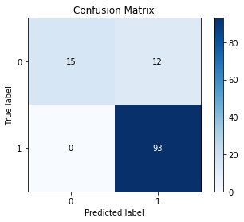

```python
skplt.metrics.plot_confusion_matrix(y_true=np.array(y_test), y_pred=predicted)
plt.show()
```

Not the best model, only 56% of skeptical tweets labeled correctly.

```python
#Try knn classifier
knn_pipeline = Pipeline([('tfidf', TfidfVectorizer(decode_error= 'ignore')),('clf', KNeighborsClassifier())])
knn_pipeline = knn_pipeline.fit(x_train, y_train)
predicted = knn_pipeline.predict(x_test)
np.mean(predicted == y_test)
```

```
0.9166666666666666
```

```python
print('\n overall accuracy:')
print(metrics.accuracy_score(y_test, predicted))

print('\n confusion_matrix:')
print(metrics.confusion_matrix(y_test, predicted))

print('\n Here is the classification report:')
print(metrics.classification_report(y_test, predicted))
```

```
 overall accuracy:
0.9166666666666666

 confusion_matrix:
[[17 10]
 [ 0 93]]

 Here is the classification report:
              precision    recall  f1-score   support

           0       1.00      0.63      0.77        27
           1       0.90      1.00      0.95        93

   micro avg       0.92      0.92      0.92       120
   macro avg       0.95      0.81      0.86       120
weighted avg       0.92      0.92      0.91       120
```

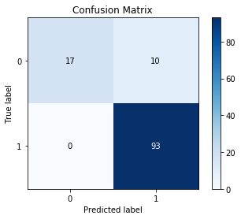

```python
skplt.metrics.plot_confusion_matrix(y_true=np.array(y_test), y_pred=predicted)
plt.show()
```

```python
#Try support vector machine
svm_pipeline = Pipeline([('tfidf', TfidfVectorizer(decode_error ='ignore')), ('clf', SVC(kernel='linear', probability=True))])
svm_pipeline = svm_pipeline.fit(x_train, y_train)
predicted = svm_pipeline.predict(x_test)
np.mean(predicted == y_test)
```

```
0.9
```

```python
#Show accuracy and confusion matrix

print('\n overall accuracy:')
print(metrics.accuracy_score(y_test, predicted))

print('\n confusion_matrix:')
print(metrics.confusion_matrix(y_test, predicted))

print('\n Here is the classification report:')
print(metrics.classification_report(y_test, predicted))
```

```
 overall accuracy:
0.9

 confusion_matrix:
[[15 12]
 [ 0 93]]

 Here is the classification report:
              precision    recall  f1-score   support

           0       1.00      0.56      0.71        27
           1       0.89      1.00      0.94        93

   micro avg       0.90      0.90      0.90       120
   macro avg       0.94      0.78      0.83       120
weighted avg       0.91      0.90      0.89       120
```

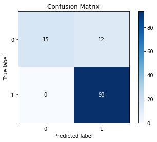

```python
skplt.metrics.plot_confusion_matrix(y_true=np.array(y_test), y_pred=predicted)
plt.show()
```

Back to 56%

```python
#Attempt nuetral network algorithm.
nn_pipeline = Pipeline([('tfidf', TfidfVectorizer(decode_error ='ignore')), ('clf', MLPClassifier())])
nn_pipeline = nn_pipeline.fit(x_train, y_train)
predicted = nn_pipeline.predict(x_test)
np.mean(predicted == y_test)
```

```
0.925
```

```python
print('\n overall accuracy:')
print(metrics.accuracy_score(y_test, predicted))

print('\n confusion_matrix:')
print(metrics.confusion_matrix(y_test, predicted))

print('\n Here is the classification report:')
print(metrics.classification_report(y_test, predicted))
```

```
 overall accuracy:
0.925

 confusion_matrix:
[[20  7]
 [ 2 91]]

 Here is the classification report:
              precision    recall  f1-score   support

           0       0.91      0.74      0.82        27
           1       0.93      0.98      0.95        93

   micro avg       0.93      0.93      0.93       120
   macro avg       0.92      0.86      0.88       120
weighted avg       0.92      0.93      0.92       120
```

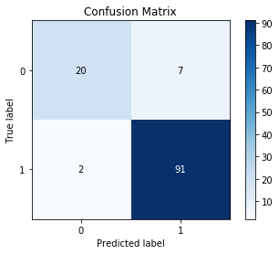

```python
skplt.metrics.plot_confusion_matrix(y_true=np.array(y_test), y_pred=predicted)
plt.show()
```

Nueral Network offers the best model for labeling the dataset.

```python
cleaned_tweets = []
for i in range(len(df_proc)):
    cleaned_tweets.append(str(df_proc.loc[i,'cleaned']))
```

```python
#Label the rest of the tweets in the data set as skeptical or not skeptical
predicted = nn_pipeline.predict(cleaned_tweets)
```

```python
#Check how many tweets fall into each category
unique, counts = np.unique(predicted, return_counts=True)

print(np.asarray((unique, counts)).T)
```

```
[['0' '45454']
 ['1' '330554']]
```

```python
#Add the labels to datafrome for further processing
df_proc['support'] = predicted
df_proc = df_proc.drop(columns=['Unnamed: 0'])
df_proc['support'] = df_proc['support'].astype(int)
df_proc.head()
```

|  | id | created at | text | screen name | followers_count | friends_count | name | hash | ment | wordcount | counts | retweet | cleaned | score | scorefl | support |
| --- | --- | --- | --- | --- | --- | --- | --- | --- | --- | --- | --- | --- | --- | --- | --- | --- |
| 0 | 1118578261108383745 | Wed Apr 17 18:13:34 +0000 2019 | RT @PickardJE: some climate change statistics ... | rawshea18 | 246.0 | 424.0 | rawshea | NaN | PickardJE | 7 | 69 | True | pickardje statistics | neutral | 0.0000 | 0 |
| 1 | 1118578260923887620 | Wed Apr 17 18:13:34 +0000 2019 | RT @toryboypierce: Withering putdown of pompo... | AndrewOldham20 | 534.0 | 76.0 | Andrew Oldham | NaN | toryboypierce adamboultonSKY | 20 | 140 | True | toryboypierce withering putdown pompous fascis... | negative | -0.7717 | 1 |
| 2 | 1118578261662027777 | Wed Apr 17 18:13:34 +0000 2019 | RT @Channel4News: This is the moment an enviro... | GhadeerAl_ | 144.0 | 149.0 | Ghadeer | NaN | Channel4News | 22 | 140 | True | channel news moment environmental lawyer glues... | neutral | 0.0000 | 1 |
| 3 | 1118578262509268999 | Wed Apr 17 18:13:34 +0000 2019 | RT @AOC: Climate change is here + we’ve got a ... | kayjoooo | 180.0 | 334.0 | ˗ˏˋ KATIE ˊˎ˗ | GreenNewDeal | AOC | 28 | 140 | True | aoc deadline years cut emissions half greennew... | negative | -0.2732 | 1 |
| 4 | 1118578264463876098 | Wed Apr 17 18:13:35 +0000 2019 | RT @AOC: Climate change is here + we’ve got a ... | BagOfLazers | 753.0 | 1712.0 | Bag Of Lazers | GreenNewDeal | AOC | 28 | 140 | True | aoc deadline years cut emissions half greennew... | negative | -0.2732 | 1 |

```python
#Check how many tweets are skeptical (0) or not skeptical (1)
df_proc['support'].value_counts()
```

```
1    330554
0     45454
Name: support, dtype: int64
```

The vast majority of tweets are not skeptical of climate change.

```python
#Check each skeptical category for sentiment
grouped = df_proc.groupby(['support', 'score'])
grouped['score'].agg(['count'])
```

| support | score | count |
| --- | --- | --- |
| 0 | negative | 4074 |
|  | neutral | 8354 |
|  | positive | 33026 |
| 1 | negative | 124408 |
|  | neutral | 85154 |
|  | positive | 120990 |

```python
#Show the average skepticism score in each sentiment category
df_proc.groupby('score').support.mean()
```

```
score
negative    0.968291
neutral     0.910660
positive    0.785568
Name: support, dtype: float64
```

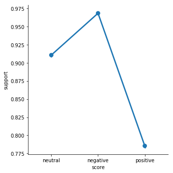

```python
#Factor plot for average skepticism in each sentiment category
sns.factorplot("score", "support", data=df_proc)
```

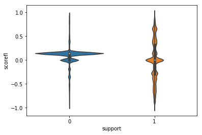

```python
#Visualize the sentiment in each skepticism category
sns.violinplot(x='support', y='scorefl', data= df_proc)
```

```python
#Repeat analysis for 2015 tweets
sample = df2015['tweets'].sample(n=100, random_state=1)
sample.to_csv('sample2015.csv', )
```

```python
#Import 100 tweets with labels
data = []

openfile = open('sample2015labeled.csv', 'r', encoding='utf-8' )

r = csv.reader(openfile)

for i in r:
    data.append([i[1], i[2]])

openfile.close()
len(data)
```

```
100
```

```python
#Create dataframe for data processing
sample_2015lab = pd.DataFrame(data)
sample_2015lab.head()
```

|  | 0 | 1 |
| --- | --- | --- |
| 0 | couldyoucope scientists call action disease ri... | 1 |
| 1 | parasiempre qmccauley climate change exist con... | 1 |
| 2 | pbrown colorado firefighters speak climatechan... | 1 |
| 3 | ssgovforum education webinar facebook http zpn... | 1 |
| 4 | ecomanleader eco climateenergy living science ... | 1 |

```python
#Store data in appropriate list
cleaned_list = []
cleaned_data = []
cleaned_labels = []
for i in range(len(sample_2015lab)):
    cleaned_list.append([sample_2015lab.loc[i,0],sample_2015lab.loc[i,1]])
    cleaned_data.append(sample_2015lab.loc[i,0])
    cleaned_labels.append(sample_2015lab.loc[i,1])
```

```python
#Vectorize data
tfidf_vectorizer = TfidfVectorizer(decode_error ='ignore')
tfidf = tfidf_vectorizer.fit_transform(cleaned_data)
print(tfidf.shape)
```

```
(100, 797)
```

```python
#Create Matrix
tfidf_matrix = tfidf_vectorizer.fit_transform(cleaned_data).toarray()
```

```python
# Split validation for classification processing
x_train, x_test, y_train, y_test = train_test_split(cleaned_data, cleaned_labels, test_size=0.3, random_state=0)
```

```python
#Attempt nuetral network algorithm.
nn_pipeline = Pipeline([('tfidf', TfidfVectorizer(decode_error ='ignore')), ('clf', MLPClassifier())])
nn_pipeline = nn_pipeline.fit(x_train, y_train)
predicted = nn_pipeline.predict(x_test)
np.mean(predicted == y_test)
```

```
0.9333333333333333
```

```python
print('\n overall accuracy:')
print(metrics.accuracy_score(y_test, predicted))

print('\n confusion_matrix:')
print(metrics.confusion_matrix(y_test, predicted))

print('\n Here is the classification report:')
print(metrics.classification_report(y_test, predicted))
```

```
 overall accuracy:
0.9333333333333333

 confusion_matrix:
[[ 0  2]
 [ 0 28]]

 Here is the classification report:
              precision    recall  f1-score   support

           0       0.00      0.00      0.00         2
           1       0.93      1.00      0.97        28

   micro avg       0.93      0.93      0.93        30
   macro avg       0.47      0.50      0.48        30
weighted avg       0.87      0.93      0.90        30
```

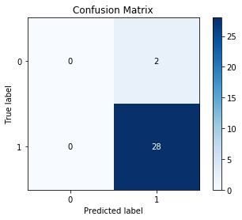

```python
skplt.metrics.plot_confusion_matrix(y_true=np.array(y_test), y_pred=predicted)
plt.show()
```

```python
cleaned_2015 = []
for i in range(len(df2015)):
    cleaned_2015.append(str(df2015.loc[i,'tweets']))
```

```python
#Predict HR or movie for the 12 unlabeled articles.
predicted = nn_pipeline.predict(cleaned_2015)
```

```python
#Attach labels to dataframe for futher processing
df2015['support'] = predicted
df2015['support'] = df2015['support'].astype(int)
df2015.head()
```

|  | tweets | score | scorefl | support |
| --- | --- | --- | --- | --- |
| 0 | karenagold scheduled burn today never mind wil... | neutral | 0.0000 | 1 |
| 1 | dflessner former bush epa chief says watts bar... | positive | 0.6369 | 1 |
| 2 | tomfeyer beyond pope message climate change ht... | neutral | 0.0000 | 1 |
| 3 | oandg advice invisible organisms threaten make... | negative | -0.6908 | 1 |
| 4 | corinnathomas climate change concern ovr yrs b... | negative | -0.4215 | 1 |

```python
#Check how many tweets in each skepticism category
df2015['support'].value_counts()
```

```
1    979
0     21
Name: support, dtype: int64
```

Not too many skeptical tweets in 2015

```python
#Create sample for manual labeling
sample = df2011['tweets'].sample(n=100, random_state=1)
sample.to_csv('sample2011.csv', )
```

```python
#Import 100 tweets with labels
data = []

openfile = open('sample2011labeled.csv', 'r', encoding='utf-8' )

r = csv.reader(openfile)

for i in r:
    data.append([i[1], i[2]])

openfile.close()
len(data)
```

```
100
```

```python
#Create dataframe for data processing
sample_2011lab = pd.DataFrame(data)
sample_2011lab.head()
```

|  | 0 | 1 |
| --- | --- | --- |
| 0 | greendreamjobs director climate change skoll g... | 1 |
| 1 | sangheepark tornadoes climate change blame dev... | 1 |
| 2 | welvarend tornado activity caused simple weath... | 1 |
| 3 | scvzla cuba identificalos latest climate chang... | 0 |
| 4 | lorion mexico big fail seen space http tinyurl... | 1 |

```python
#Store data in appropriate list
cleaned_list = []
cleaned_data = []
cleaned_labels = []
for i in range(len(sample_2011lab)):
    cleaned_list.append([sample_2011lab.loc[i,0],sample_2015lab.loc[i,1]])
    cleaned_data.append(sample_2011lab.loc[i,0])
    cleaned_labels.append(sample_2011lab.loc[i,1])
```

```python
#Vectorize data
tfidf_vectorizer = TfidfVectorizer(decode_error ='ignore')
tfidf = tfidf_vectorizer.fit_transform(cleaned_data)
print(tfidf.shape)
```

```
(100, 720)
```

```python
#Create Matrix
tfidf_matrix = tfidf_vectorizer.fit_transform(cleaned_data).toarray()
```

```python
# Split validation for classification processing
x_train, x_test, y_train, y_test = train_test_split(cleaned_data, cleaned_labels, test_size=0.3, random_state=0)
```

```python
#Attempt nuetral network algorithm.
nn_pipeline = Pipeline([('tfidf', TfidfVectorizer(decode_error ='ignore')), ('clf', MLPClassifier())])
nn_pipeline = nn_pipeline.fit(x_train, y_train)
predicted = nn_pipeline.predict(x_test)
np.mean(predicted == y_test)
```

```
0.9666666666666667
```

```python
print('\n overall accuracy:')
print(metrics.accuracy_score(y_test, predicted))

print('\n confusion_matrix:')
print(metrics.confusion_matrix(y_test, predicted))

print('\n Here is the classification report:')
print(metrics.classification_report(y_test, predicted))
```

```
 overall accuracy:
0.9666666666666667

 confusion_matrix:
[[ 2  1]
 [ 0 27]]

 Here is the classification report:
              precision    recall  f1-score   support

           0       1.00      0.67      0.80         3
           1       0.96      1.00      0.98        27

   micro avg       0.97      0.97      0.97        30
   macro avg       0.98      0.83      0.89        30
weighted avg       0.97      0.97      0.96        30
```

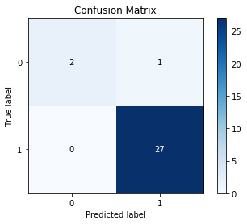

```python
skplt.metrics.plot_confusion_matrix(y_true=np.array(y_test), y_pred=predicted)
plt.show()
```

```python
cleaned_2011 = []
for i in range(len(df2011)):
    cleaned_2011.append(str(df2011.loc[i,'tweets']))
```

```python
#Predict HR or movie for the 12 unlabeled articles.
predicted = nn_pipeline.predict(cleaned_2011)
```

```python
#Add skepticism to dataframe for further processing
df2011['support'] = predicted
df2011['support'] = df2011['support'].astype(int)
df2011.head()
```

|  | tweets | score | scorefl | support |
| --- | --- | --- | --- | --- |
| 0 | droughtdoctor colleagues packaged basic scienc... | negative | -0.4767 | 1 |
| 1 | innovation new post stark warnings potential r... | positive | 0.4588 | 1 |
| 2 | mattstrand excellent video climate change impa... | positive | 0.5719 | 1 |
| 3 | yolibeans recognised one main causes climate c... | neutral | 0.0000 | 1 |
| 4 | earthknowledge unfccc climate change responsib... | negative | -0.4939 | 1 |

```python
#Show the number of tweets that fall into each skepticism category
df2011['support'].value_counts()
```

```
1    957
0     43
Name: support, dtype: int64
```

```python
df2019=df_proc[['score', 'scorefl', 'support']]
df2011=df2011.drop(columns=['tweets'])
df2015=df2015.drop(columns=['tweets'])
```

```python
df2019['year'] = 2019
df2015['year'] = 2015
df2011['year'] = 2011
```

```python
dfyear = df2019.append(df2015)
```

```python
dfyear = dfyear.append(df2011)
```

```python
dfyear.groupby(['year']).mean()
```

| year | scorefl | support |
| --- | --- | --- |
| 2011 | -0.116229 | 0.957000 |
| 2015 | -0.017462 | 0.979000 |
| 2019 | 0.004290 | 0.879114 |

[figure not shown]

```python
sns.factorplot("support", "score", "year", data=dfyear, kind="bar",
               size=6, aspect=2, palette="muted")
```